# COMPSCIX 415.2 Homework 7

Rachel Hollowgrass

3/20/2018

```r
# load packages
library(tidyverse)
library(broom)
```

### Exercise 1

Load the train.csv dataset into R. How many observations and columns are there?

```r
file_path <- '../data/train.csv'
train <- read_csv(file_path)
```

*There are:*

- *1460 observations*
- *80 columns of variables (not including the ID number)*

### Exercise 2

Normally at this point you would spend a few days on EDA, but for this homework we will get right to fitting some linear regression models.

Our first step is to randomly split the data into train and test datasets. We will use a 70/30 split. There is an R package that will do the split for you, but let’s get some more practice with R and do it ourselves by filling in the blanks in the code below.

```r
# When taking a random sample, it is often useful to set a seed so that
# your work is reproducible. Setting a seed will guarantee that the same
# random sample will be generated every time, so long as you always set the
# same seed beforehand
set.seed(29283)

# This data already has an Id column which we can make use of.
# Let's create our training set using sample_frac. Fill in the blank.
train_set <- train %>% sample_frac(.7)

# let's create our testing set using the Id column. Fill in the blanks.
test_set <- train %>% filter(!(train$Id %in% train_set$Id))
```

### Exercise 3

Our target is called `SalePrice`. First, we can fit a simple regression model consisting of only the intercept (the average of SalePrice). Fit the model and then use the broom package to

- take a look at the coefficient,  
  *The coefficient (intercept) is 182176.*
- compare the coefficient to the average value of SalePrice, and  
  *The average value (mean) of SalePrice is also 182176.*
- take a look at the R-squared.  
  *The R-squared is 0, which sounds like a bad fit, but I assume it’s because of `lm(SalePrice ~ 1 …`.*

Use the code below and fill in the blanks.

```r
# Fit a model with intercept only
mod_0 <- lm(SalePrice ~ 1, data = train_set)

# Double-check that the average SalePrice is equal to our model's coefficient
mean(train_set$SalePrice)
```

```
## [1] 182176
```

```r
tidy(mod_0)
```

```
##          term estimate std.error statistic p.value
## 1 (Intercept)   182176  2492.072  73.10222       0
```

```r
# Check the R-squared
glance(mod_0)
```

```
##   r.squared adj.r.squared    sigma statistic p.value df    logLik      AIC
## 1         0             0 79668.37        NA      NA  1 -12983.57 25971.13
##        BIC     deviance df.residual
## 1 25980.99 6.480338e+12        1021
```

### Exercise 4

Now fit a linear regression model using `GrLivArea`, `OverallQual`, and `Neighborhood` as the features. Don’t forget to look at `data_description.txt` to understand what these variables mean. Ask yourself these questions before fitting the model:

- What kind of relationship will these features have with our target?  
  *Three features seem like reasonable choices for modeling the target, SalePrice. Location (`Neighborhood`), size (`GrLivArea`), and appearance (`OverallQual`) are often how people decide on a house to buy.*
- Can the relationship be estimated linearly?  
  *Of the three selected features, `GrLivArea` and `OverallQual` are quantitative, while `Neighborhood` stands out as an unordered categorical variable. The values for `Neighborhood` could perhaps be ordered by using the mean property per neighborhood, or similar measure. Also, there are 25 Neighborhoods. If there are few observations for some Neighborhoods, the significance may be poor.*
- Are these good features, given the problem we are trying to solve?  
  *It seems likely. If I were buying a house I might have considered `OverallCond` instead of `OverallQual` because I prioritize fewer future repairs over nicer appearance. The buying public probably differs there. Also, I wondered about walkability and proximity to sevices, but I did not see anything like either in the data description file. Those qualities may be more of an urban concept than fits Ames IA.*

```r
# Fit a model to three features:
mod_1 <- lm(SalePrice ~ GrLivArea + OverallQual + Neighborhood, data = train_set)

# Check the R-squared
tidy(mod_1)
```

```
##                   term     estimate    std.error  statistic      p.value
## 1          (Intercept) -45017.87483 12933.341808 -3.4807612 5.216927e-04
## 2            GrLivArea     62.77735     3.006033 20.8837885 1.337222e-80
## 3          OverallQual  21692.23178  1353.714104 16.0242342 1.389020e-51
## 4  NeighborhoodBlueste -38288.88063 36531.907177 -1.0480942 2.948497e-01
## 5   NeighborhoodBrDale -43314.05372 14524.693991 -2.9820975 2.932566e-03
## 6  NeighborhoodBrkSide -14064.37052 11318.850018 -1.2425618 2.143221e-01
## 7  NeighborhoodClearCr  27839.00662 13561.346871  2.0528202 4.035110e-02
## 8  NeighborhoodCollgCr   4297.67432 10372.304467  0.4143413 6.787135e-01
## 9  NeighborhoodCrawfor   7423.05573 11371.511784  0.6527765 5.140512e-01
## 10 NeighborhoodEdwards -15284.11495 10994.287187 -1.3901870 1.647830e-01
## 11 NeighborhoodGilbert  -8357.55930 10894.173472 -0.7671586 4.431692e-01
## 12  NeighborhoodIDOTRR -32689.43085 12603.712743 -2.5936350 9.636216e-03
## 13 NeighborhoodMeadowV -14446.06504 14190.148622 -1.0180348 3.089089e-01
## 14 NeighborhoodMitchel   1922.31487 11788.608170  0.1630655 8.705000e-01
## 15   NeighborhoodNAmes  -7719.67883 10375.956174 -0.7439969 4.570540e-01
## 16 NeighborhoodNoRidge  47685.16790 12567.432633  3.7943444 1.569690e-04
## 17 NeighborhoodNPkVill -20240.71145 16548.664867 -1.2231024 2.215806e-01
## 18 NeighborhoodNridgHt  63872.80848 10880.456671  5.8704161 5.917964e-09
## 19  NeighborhoodNWAmes -12279.33299 11047.502893 -1.1115030 2.666204e-01
## 20 NeighborhoodOldTown -36107.07577 10849.170903 -3.3280954 9.064637e-04
## 21  NeighborhoodSawyer  -4121.92502 11252.369778 -0.3663162 7.142070e-01
## 22 NeighborhoodSawyerW  -5391.97074 11230.758221 -0.4801075 6.312565e-01
## 23 NeighborhoodSomerst  18700.96725 10772.212794  1.7360377 8.286672e-02
## 24 NeighborhoodStoneBr  65712.45881 12745.312907  5.1558137 3.045915e-07
## 25   NeighborhoodSWISU -45451.86707 13564.792586 -3.3507233 8.363074e-04
## 26  NeighborhoodTimber  27925.08619 11985.325857  2.3299397 2.000859e-02
## 27 NeighborhoodVeenker  54913.12768 16521.075497  3.3238228 9.203087e-04
```

```r
glance(mod_1)
```

```
##   r.squared adj.r.squared   sigma statistic p.value df    logLik      AIC
## 1 0.8099927     0.8050277 35178.1  163.1401       0 27 -12134.95 24325.91
##        BIC     deviance df.residual
## 1 24463.93 1.231311e+12         995
```

After fitting the model, output the coefficients and the R-squared using the broom package.

### Exercise 5

Evaluate the model on test_set using the root mean squared error (RMSE). Use the `predict` function to get the model predictions for the testing set. Recall that RMSE is the square root of the mean of the squared errors:

Hint: use the `sqrt()` and `mean()` functions:

```r
# The code below keeps giving me an error, which I don't understand.
#    Error in Ops.data.frame(test_set, mod_1) : list of length 13 not meaningful
#
# For that reason, I'm commenting out the code:
#
# test_predictions <- predict(mod_1, newdata = test_set)
# rmse <- sqrt(mean((test_set - mod_1)^2))
```

### Exercise 6 (OPTIONAL - won’t be graded)

Feel free to play around with linear regression. Add some other features and see how the model results change. Test the model on test_set to compare the RMSE’s.

### Exercise 7

One downside of the linear model is that it is sensitive to unusual values because the distance incorporates a squared term. Fit a linear model to the simulated data below, and visualise the results. Rerun a few times to generate different simulated datasets. What do you notice about the model?

*For the three runs I notice that the confidence interval is consistently narrower in the middle of the range, around x = 5.*

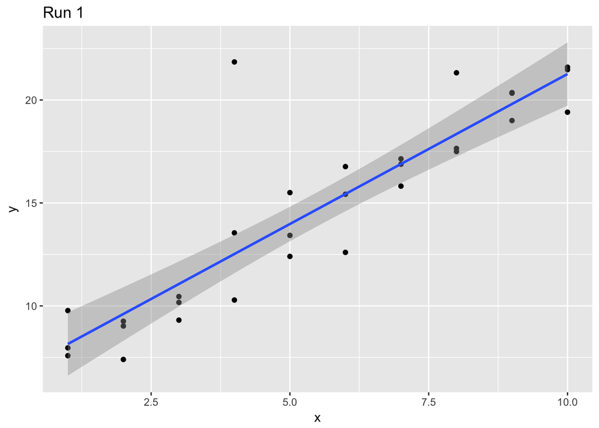

```r
sim1a1 <- tibble(
   x = rep(1:10, each = 3),
   y = x * 1.5 + 6 + rt(length(x), df = 2)
 )

ggplot(sim1a1, aes(x, y)) +
  geom_point() +
  geom_smooth(method='lm') +
  ggtitle("Run 1")
```

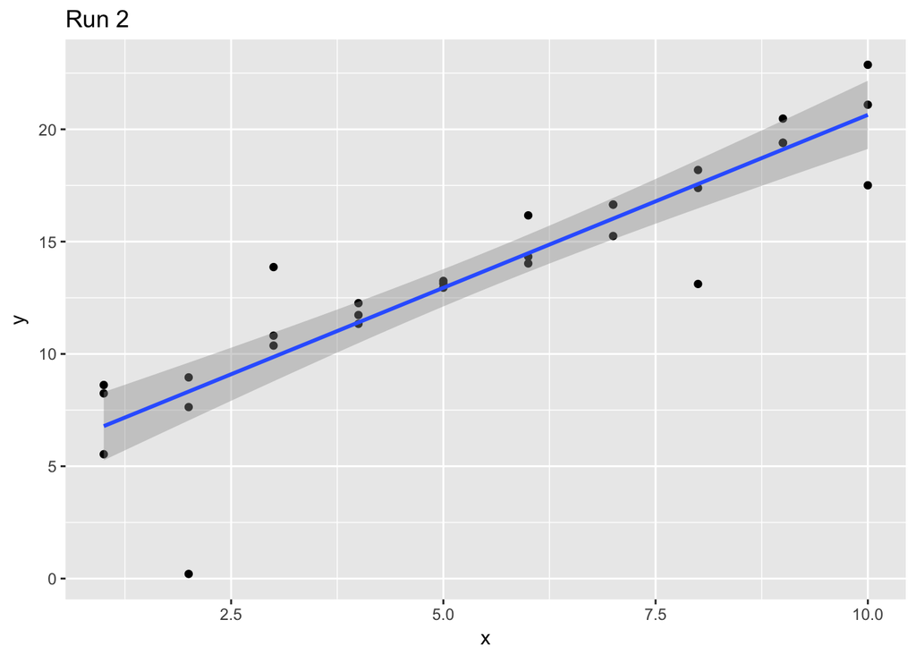

```r
sim1a2 <- tibble(
   x = rep(1:10, each = 3),
   y = x * 1.5 + 6 + rt(length(x), df = 2)
 )

ggplot(sim1a2, aes(x, y)) +
  geom_point() +
  geom_smooth(method='lm') +
  ggtitle("Run 2")
```

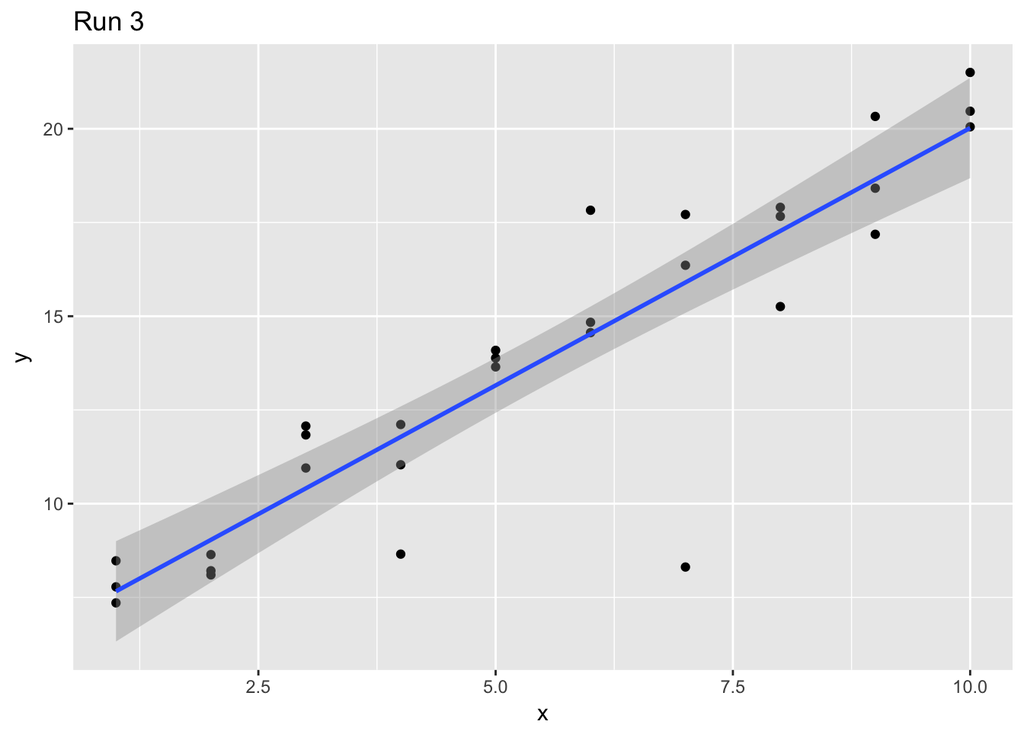

```r
sim1a3 <- tibble(
   x = rep(1:10, each = 3),
   y = x * 1.5 + 6 + rt(length(x), df = 2)
 )

ggplot(sim1a3, aes(x, y)) +
  geom_point() +
  geom_smooth(method='lm') +
  ggtitle("Run 3")
```